[Home](https://canholyavkin.github.io) - [Other Posts](https://canholyavkin.github.io/#blog) - Contact

# DNA Dalgaboyu: 260nm

İlk Minimal Sentetik Bakteri

DNA veya RNA izolasyonu sonrasında, konsantrasyon ve saflıkların ölçülmesi için (Nanodrop™ ve benzeri) spektrofotometreler kullanılır. Bu cihazlar, izolasyon sonrası elde edilen DNA’ın miktar ve saflıklarını ifade eden değerler verir. Örnek konsantrasyonuna ek olarak, okunan değerler arasında **A260/230** ve **A260/280** gibi parametreler de bulunur. Peki bu değerler ne anlama gelir? Yüksek veya düşük olması neyi ifade eder?

# Absorbans Nedir

Spektrofotometreler, temel olarak sıvı örneğe belli bir dalgaboyunda ışık gönderdikten sonra bunun ne kadarının sıvı içerisinde absorbe edilmeden geçip gittiğini ölçer. Sıvının içindeki madde ne kadar fazla ise soğurulan ışığın miktarı o kadar fazla olur. Gönderilen ve geçen ışık miktarının oranından, absorbans adı verilen [optik yoğunluk değeri](https://en.0wikipedia.org/wiki/Absorbance) (OD) ölçülür.

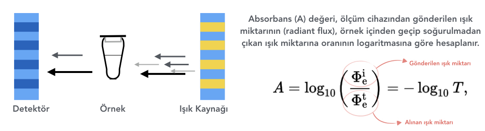

[Beer Lambert kanunu](https://en.0wikipedia.org/wiki/Beer–Lambert_law), absorbans ile konsantrasyon arasında doğrudan bir korelasyon olduğunu gösterir. Nükleik asitler bir çok dalgaboyunda absorbans gösterse de, maksimum soğurma yaptığı ışık 260 nm dalgaboyundadır. Bu dalgaboyunda DNA’nın yaptığı soğurma miktarı, Beer Lambert kanunu ile konsantrasyona çevrilebilir. Absorbans ile konsantrasyon arası ilişki 0.1 ile 1.0 arası absorbans için geçerlidir. **Bu değerler DNA konsantrasyonu açısından 2 ng/µl ile 15000 ng/µl konsantrasyonlarına denk gelir. Bu değerlerin dışındaki ölçümler gerçek değeri yansıtmayabilir.** [^1]

# DNA 260, Protein 280…

Her madde, kimyasal yapısına göre farklı dalgaboylarındaki ışığı soğurur. DNA ve proteinler için konuştuğumuzda, bu soğurma kimyasal yapılarındaki halkalar tarafından gerçekleşir. Işık kaynağından gelen foton, halkasal yapılardaki pi orbitallerini uyarır ve foton soğurularak enerjiye çevrilir. Bu sebeple spektrofotometrik DNA ölçümleri, pi konjüge sistemlerine sahip halkasal moleküllerde gerçekleşir. Nükleotitlerde bu soğurma azotlu baz üzerindeki halkasal yapılar tarafından gerçekleşir ve ağırlıklı olarak 260 nm dalgaboyundaki ışığı soğurur. DNA ve RNA’yı oluşturan nükleotitler özellikle 260 nm’de absorbans gösterdiği için, DNA ölçümlerinde de bu dalgaboyu kullanılarak DNA miktarı analiz edilir.

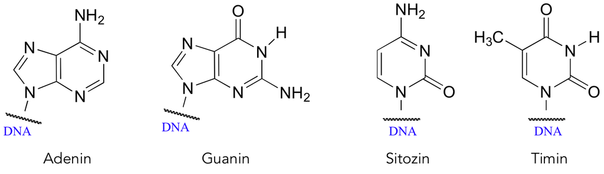

Proteinlerde ise Tirozin, Fenilalanin ve Triptofan amino asitlerinde yer alan halkalar büyük oranda 280 nm dalgaboyundaki ışığı soğurur.

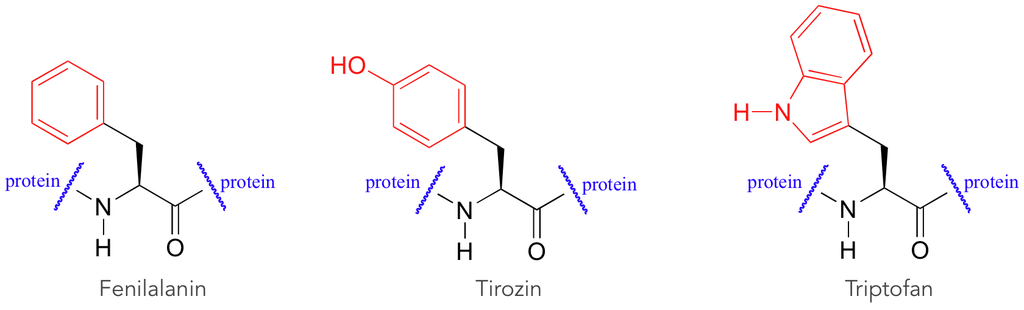

# 260 nm

# 280 nm

Bu dalgaboyu genellikle amino asit ve fenolik bileşikler tarafından soğurulur. Halkasal yapıya sahip amino asitleri (triptofan, fenilalanin, tirozin ve histidin) içeren proteinlerin varlığında bu dalgaboyunda soğurma görülür.

# 230 nm

Çoğu organik molejül 225 nm’de yüksek absorbans’a sahiptir. Bunların içinde fenol, TRIzol çeşitli tuzlar yer alır. Ayrıca proteinler içindeki peptit bağları da 200 ile 230 nm arasındaki dalgaboyları arasında absorbans gösterir.

# A260/280 Oranı

260/280 oranı genellikle örnek içindeki protein kontaminasyonunu belirlemek için kullanılır. Saf DNA örneklerinde bu oran yaklaşık 1.8; saf DNA örneklerinde ise bu oran yaklaşık 2.1’dir. Halkasal yapıya sahip (aromatik) proteinler 280 nm’de yüksek absorbans gösterirler. Bu sebeple örnekteki protein kontaminasyonu arttıkça 260/280 oranı azalır. RNA örneklerinin daha 260/280 değerine sahip olmasının sebebi, RNA’da bulunan urasil’in DNA’daki timin’e kıyasla 3 kat daha fazla absorbans göstermesidir.

# A260/230 Oranı

260/230 oranı, örnek içindeki organik kontaminantların varlığını ölçmek için kullanılır. Bunlar genellikle DNA veya RNA izolasyonunda kullanılan uygulanan metotlardan kalan artıkları oluşturur. Örneğin, TRIzol ve fenol gibi. Bu aromatik moleküller ağırlıklı olarak 225-230 nm arasında absorbans gösterdiği için ortamdaki miktarları arttığında 260/230 oranını düşürürler. Genellikle bu değerinde 1.8’in altına düştüğü durumlarda sonraki basamakları etkileyebilirler. Saf bir örnekte bu değer 2.0’a yakındır.

# Kısa Notlar

**Can Holyavkin**

E-posta | [Linkedin](https://www.linkedin.com/in/can-holyavkin/) | [Twitter](https://twitter.com/CanHolyavkin)